# CoMMpass S5 spectra GSEA 20220715

```r
library(readr)
library(dplyr)
library(tidyr)
library(fgsea)
library(ggplot2)
```

## bring in the data

### CoMMpass rotation matrix

```r
cmps_spec_rm <-
  read_csv("~/Documents/stats/survival/commpass_proj/spectra_commpass_product/CoMMpass_inclfollowup_final_SpectraData_20210601/spectra_rotation_matrix-gene_centers-2021-06-01.csv.gz")
```

bring in gene annotation to get gene names

```r
gencode_annot <-
  read_csv("~/Documents/stats/survival/commpass_proj/commpass_spectra/Homo_sapiens.GRCh37.74.gtf.flat.csv")
```

```r
gid_names <- gencode_annot %>% distinct(gene_id, .keep_all = T) %>% select(gene_id, gene_name)
```

```r
cmps_spec_rm_wn <- left_join(cmps_spec_rm, gid_names, by="gene_id") %>%
  select(-mean) %>%
  relocate(gene_name)
```

are there any duplicate gene_names?

```r
cmps_spec_rm_wn %>%
    add_count(gene_name) %>%
    filter(n>1) %>%
  select(gene_name, gene_id, n)
```

| gene_name | gene_id | n |
| --- | --- | --- |
| PAGR1 | ENSG00000185928 | 2 |
| PAGR1 | ENSG00000263136 | 2 |

crap, yes there is one, these were apparently combined later. just going to leave them and see how it goes…

### gene sets

minimal description of collections and where to get them:  
https://www.gsea-msigdb.org/gsea/msigdb/collections.jsp

a bit more detail info on collections:  
https://www.gsea-msigdb.org/gsea/msigdb/collection_details.jsp

`hallmark`

```r
hallmark <- gmtPathways("h.all.v7.4.symbols.gmt")
```

this is the `Hallmark` set, which is kind of a meta set derived from multiple other sets in the MSigDB that reduces redundancy  
https://www.cell.com/cell-systems/fulltext/S2405-4712(15)00218-5

`cannonical`

```r
c2_cannonical <- gmtPathways("c2.cp.v7.4.symbols.gmt")
```

this is the `canonical pathways` subset of the `c2` collection:  
https://www.gsea-msigdb.org/gsea/msigdb/genesets.jsp?collection=CP

`ontology`

```r
c5_ontology <- gmtPathways("c5.all.v7.4.symbols.gmt")
```

entire `c5` collection described as `ontology gene sets` https://www.gsea-msigdb.org/gsea/msigdb/genesets.jsp?collection=C5  
GO (gene ontology) gene sets: http://amigo.geneontology.org/amigo  
GO:BP (GO biological process, 7481 gene sets)  
GO:CC (GO cellular component, 996 gene sets)  
GO:MF (GO molecular function, 1708 gene sets)  
and  
HPO (Human Phenotye Ontology, 4813 gene sets): https://hpo.jax.org/app/

## CoMMpass spectra associated with survival outcomes

the following spectra are significant in the CoxPH model  
OS: Sp2 + Sp3 + Sp4 + Sp5 + Sp9 + Sp12 + Sp13 + Sp19 + Sp26  
PFS: Sp1 + Sp2 + Sp4 + Sp5 + Sp9 + Sp11 + Sp24 + Sp26 + Sp32  
TTF: Sp1 + Sp2 + Sp4 + Sp5 + Sp9 + Sp10 + Sp18 + Sp24 + Sp31 + Sp32

fgsea needs preranked vector with names where names are gene names

### Sp5 (OS, PFS, TTF)

```r
Sp5 <- cmps_spec_rm_wn$PC5
names(Sp5) <- cmps_spec_rm_wn$gene_name
head(Sp5,12)
```

```
        DPM1        SCYL3        FUCA2         GCLC         NFYA        STPG1       NIPAL3        LAS1L
 0.012052857 -0.011867360  0.041470608 -0.005676484 -0.002013846  0.013017143  0.003330297 -0.004199684
       ENPP4       ANKIB1        KRIT1        RAD52
 0.025837637 -0.005557352  0.004411775 -0.006967890
```

```r
Sp5 <- sort(Sp5, decreasing=T)
head(Sp5,12)
```

```
       MDK      MOXD1       SELM      DERL3     MFSD2A      PHGDH       CST3     SMIM14       HEY2      P2RX1
0.07398958 0.07225790 0.06125868 0.06112105 0.05759417 0.05695541 0.05689918 0.05613984 0.05606685 0.05425998
      MZB1   SERPINI1
0.05409411 0.05359924
```

#### hallmark pathways

```r
set.seed(2213)
fgseaSp5_hm <- fgsea(pathways = hallmark,
                  stats = Sp5,
                  minSize=15,
                  maxSize=1000,
                  eps=0)
```

```r
fgseaSp5_hm[order(pval), ]
```

| pathway | pval | padj | log2err | ES | NES | size | leadingEdge |
| --- | --- | --- | --- | --- | --- | --- | --- |
| HALLMARK_E2F_TARGETS | 1.271750e-24 | 5.850049e-23 | 1.28710367 | -0.6715619 | -3.1525122 | 125 |  |
| HALLMARK_G2M_CHECKPOINT | 9.959550e-16 | 2.290696e-14 | 1.01754480 | -0.5811314 | -2.7071315 | 123 |  |
| HALLMARK_UNFOLDED_PROTEIN_RESPONSE | 1.652114e-09 | 2.533241e-08 | 0.78818681 | 0.6163007 | 2.2549214 | 85 |  |
| HALLMARK_MITOTIC_SPINDLE | 2.360044e-07 | 2.714051e-06 | 0.69013246 | -0.4428559 | -2.0895861 | 126 |  |
| HALLMARK_EPITHELIAL_MESENCHYMAL_TRANSITION | 1.409034e-05 | 1.296311e-04 | 0.59332548 | 0.6549476 | 2.1203334 | 37 |  |
| HALLMARK_GLYCOLYSIS | 2.047529e-05 | 1.569772e-04 | 0.57561026 | 0.4980890 | 1.8757625 | 98 |  |
| HALLMARK_MYC_TARGETS_V1 | 2.132851e-04 | 1.249632e-03 | 0.51884808 | -0.3519642 | -1.6689894 | 143 |  |
| HALLMARK_HYPOXIA | 2.173273e-04 | 1.249632e-03 | 0.51884808 | 0.4787307 | 1.7830976 | 93 |  |
| HALLMARK_XENOBIOTIC_METABOLISM | 8.751869e-04 | 4.223359e-03 | 0.47727082 | 0.4660723 | 1.6859685 | 78 |  |
| HALLMARK_P53_PATHWAY | 9.671632e-04 | 4.223359e-03 | 0.47727082 | 0.4350882 | 1.6630265 | 110 |  |

[output cut: 36 more lines]

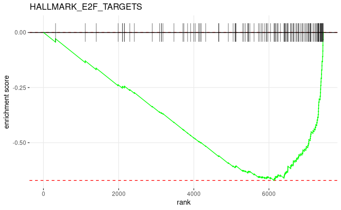

```r
plotEnrichment(hallmark[[fgseaSp5_hm[order(pval), ]$pathway[1]]],
               Sp5) + labs(title=fgseaSp5_hm[order(pval), ]$pathway[1])
```

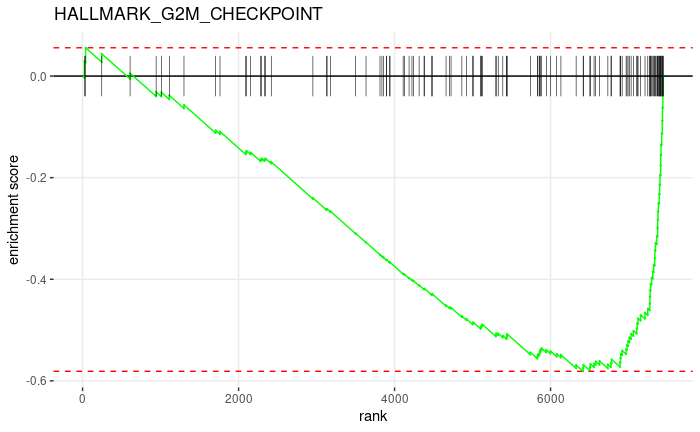

```r
plotEnrichment(hallmark[[fgseaSp5_hm[order(pval), ]$pathway[2]]],
               Sp5) + labs(title=fgseaSp5_hm[order(pval), ]$pathway[2])
```

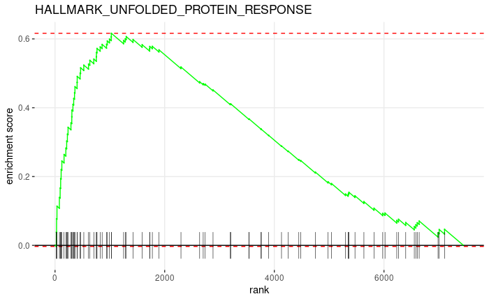

```r
plotEnrichment(hallmark[[fgseaSp5_hm[order(pval), ]$pathway[3]]],
               Sp5) + labs(title=fgseaSp5_hm[order(pval), ]$pathway[3])
```

##### leading edge analaysis

```r
he2f <- fgseaSp5_hm %>% filter(pathway=="HALLMARK_E2F_TARGETS") %>% pull(leadingEdge) %>% unlist()
hg2m <- fgseaSp5_hm %>% filter(pathway=="HALLMARK_G2M_CHECKPOINT") %>% pull(leadingEdge) %>% unlist()
hupr <- fgseaSp5_hm %>% filter(pathway=="HALLMARK_UNFOLDED_PROTEIN_RESPONSE") %>% pull(leadingEdge) %>% unlist()
```

```r
intersect(he2f, hg2m)
```

```
 [1] "MKI67"  "MCM2"   "MYC"    "SMC4"   "STMN1"  "TACC3"  "EZH2"   "MCM3"   "MCM6"   "CHEK1"  "TMPO"   "LBR"
[13] "MAD2L1" "MCM5"   "MYBL2"  "POLE"   "RAD21"  "BARD1"  "CKS1B"  "XPO1"   "POLA2"  "CKS2"   "LMNB1"  "KIF22"
[25] "ILF3"   "SRSF1"
```

```r
hupr
```

```
 [1] "SLC7A5"   "ATF3"     "CHAC1"    "WIPI1"    "PSAT1"    "PDIA5"    "HERPUD1"  "BAG3"     "HSP90B1"
[10] "HSPA5"    "WFS1"     "FKBP14"   "SPCS3"    "SRPRB"    "DNAJC3"   "PDIA6"    "DDIT4"    "ATF4"
[19] "SERP1"    "CEBPB"    "CALR"     "ASNS"     "ATP6V0D1" "EIF4EBP1" "EDEM1"    "HYOU1"    "PREB"
[28] "SLC30A5"  "ATF6"     "ALDH18A1" "SLC1A4"   "XPOT"     "SEC31A"   "EDC4"     "SSR1"     "SEC11A"
[37] "EIF4G1"   "ARFGAP1"
```

#### c2 cannonical pathways

```r
set.seed(2621)
fgseaSp5_cp <- fgsea(pathways = c2_cannonical,
                  stats = Sp5,
                  minSize=15,
                  maxSize=1000,
                  eps=0)
```

```r
head(fgseaSp5_cp[order(pval), ], 100)
```

| pathway | pval | padj | log2err | ES | NES | size | leadingEdge |
| --- | --- | --- | --- | --- | --- | --- | --- |
| REACTOME_ASPARAGINE_N_LINKED_GLYCOSYLATION | 1.925247e-14 | 2.433512e-11 | 0.9759947 | 0.5660351 | 2.291543 | 188 |  |
| REACTOME_CELL_CYCLE_MITOTIC | 5.424555e-12 | 3.428319e-09 | 0.8870750 | -0.3892719 | -2.004949 | 314 |  |
| REACTOME_CELL_CYCLE | 1.004940e-11 | 4.234145e-09 | 0.8753251 | -0.3655296 | -1.931247 | 387 |  |
| WP_RETINOBLASTOMA_GENE_IN_CANCER | 6.500580e-11 | 2.054183e-08 | 0.8390889 | -0.6601128 | -2.645669 | 57 |  |
| REACTOME_TRANSPORT_OF_SMALL_MOLECULES | 1.931768e-08 | 4.883510e-06 | 0.7337620 | 0.4455788 | 1.855291 | 270 |  |
| REACTOME_ER_TO_GOLGI_ANTEROGRADE_TRANSPORT | 2.618341e-08 | 4.920051e-06 | 0.7337620 | 0.5732246 | 2.133688 | 94 |  |
| REACTOME_CHROMATIN_MODIFYING_ENZYMES | 2.724712e-08 | 4.920051e-06 | 0.7337620 | -0.4399730 | -2.065453 | 145 |  |
| REACTOME_UNFOLDED_PROTEIN_RESPONSE_UPR | 3.831036e-08 | 6.053037e-06 | 0.7195128 | 0.6253635 | 2.196844 | 68 |  |
| WP_DNA_REPLICATION | 6.102727e-08 | 8.570941e-06 | 0.7049757 | -0.7349666 | -2.549010 | 29 |  |
| KEGG_DNA_REPLICATION | 1.777235e-07 | 2.185459e-05 | 0.6901325 | -0.7353181 | -2.503196 | 28 |  |

[output cut: 90 more lines]

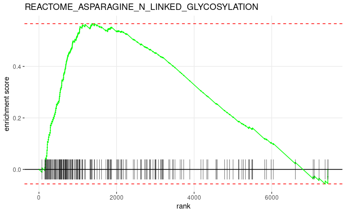

```r
plotEnrichment(c2_cannonical[[fgseaSp5_cp[order(pval), ]$pathway[1]]],
               Sp5) + labs(title=fgseaSp5_cp[order(pval), ]$pathway[1])
```

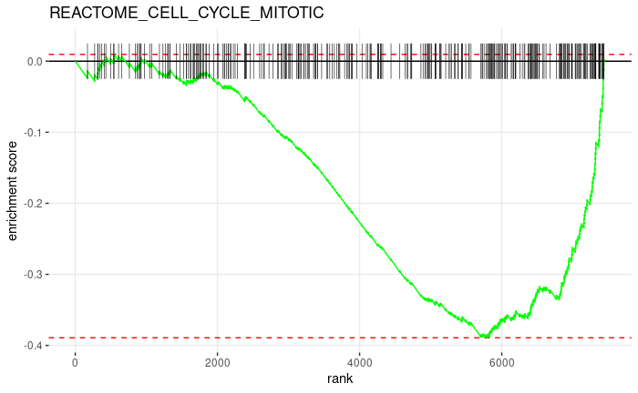

```r
plotEnrichment(c2_cannonical[[fgseaSp5_cp[order(pval), ]$pathway[2]]],
               Sp5) + labs(title=fgseaSp5_cp[order(pval), ]$pathway[2])
```

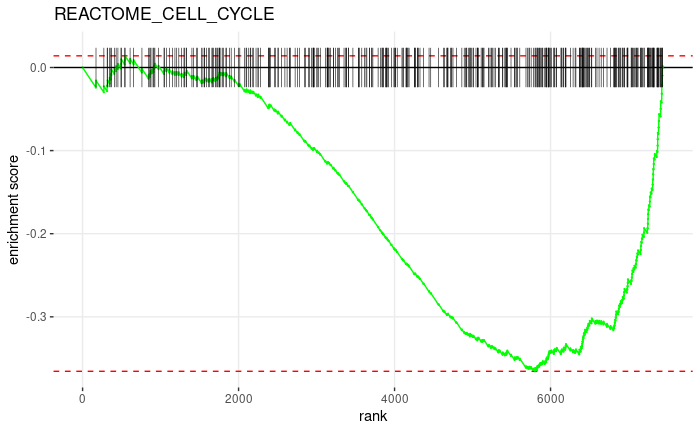

```r
plotEnrichment(c2_cannonical[[fgseaSp5_cp[order(pval), ]$pathway[3]]],
               Sp5) + labs(title=fgseaSp5_cp[order(pval), ]$pathway[3])
```

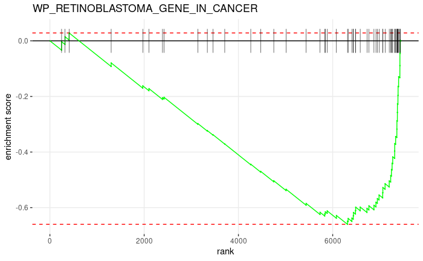

```r
plotEnrichment(c2_cannonical[[fgseaSp5_cp[order(pval), ]$pathway[4]]],
               Sp5) + labs(title=fgseaSp5_cp[order(pval), ]$pathway[4])
```

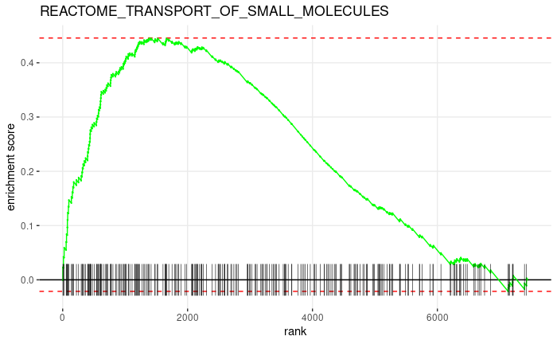

```r
plotEnrichment(c2_cannonical[[fgseaSp5_cp[order(pval), ]$pathway[5]]],
               Sp5) + labs(title=fgseaSp5_cp[order(pval), ]$pathway[5])
```

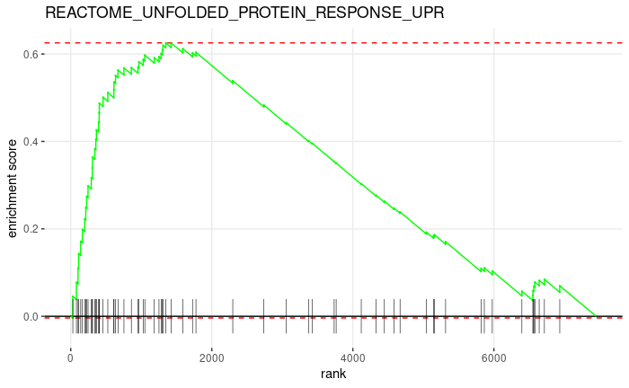

```r
plotEnrichment(c2_cannonical[[fgseaSp5_cp[order(pval), ]$pathway[8]]],
               Sp5) + labs(title=fgseaSp5_cp[order(pval), ]$pathway[8])
```

#### c5 ontology pathways

```r
set.seed(5953)
fgseaSp5_ont <- fgsea(pathways = c5_ontology,
                  stats = Sp5,
                  minSize=15,
                  maxSize=1000,
                  eps=0)
```

```r
head(fgseaSp5_ont[order(pval), ], 100)
```

| pathway | pval | padj | log2err | ES | NES | size | leadingEdge |
| --- | --- | --- | --- | --- | --- | --- | --- |
| GOCC_ENDOPLASMIC_RETICULUM | 3.729141e-32 | 1.936916e-28 | 1.4745625 | 0.4861185 | 2.141471 | 829 |  |
| GOBP_CHROMOSOME_ORGANIZATION | 1.306427e-31 | 3.392791e-28 | 1.4604515 | -0.4156204 | -2.304893 | 702 |  |
| GOCC_ORGANELLE_SUBCOMPARTMENT | 1.608968e-27 | 2.785659e-24 | 1.3651796 | 0.4659216 | 2.051890 | 858 |  |
| GOCC_NUCLEAR_OUTER_MEMBRANE_ENDOPLASMIC_RETICULUM_MEMBRANE_NETWORK | 1.939082e-21 | 2.517897e-18 | 1.1953445 | 0.4817626 | 2.098085 | 547 |  |
| GOBP_CHROMATIN_ORGANIZATION | 7.041373e-17 | 7.314578e-14 | 1.0574636 | -0.3992369 | -2.122105 | 441 |  |
| GOBP_RESPONSE_TO_ENDOPLASMIC_RETICULUM_STRESS | 8.423993e-16 | 7.292370e-13 | 1.0276699 | 0.5757240 | 2.335236 | 190 |  |
| GOBP_DNA_CONFORMATION_CHANGE | 1.487596e-15 | 1.103796e-12 | 1.0175448 | -0.5390706 | -2.571835 | 161 |  |
| GOBP_RESPONSE_TO_TOPOLOGICALLY_INCORRECT_PROTEIN | 5.874732e-15 | 3.814170e-12 | 0.9969862 | 0.6244938 | 2.438585 | 134 |  |
| GOCC_ENDOPLASMIC_RETICULUM_LUMEN | 7.415316e-15 | 4.279461e-12 | 0.9865463 | 0.6762611 | 2.511289 | 94 |  |
| GOCC_GOLGI_APPARATUS | 2.207199e-14 | 1.146419e-11 | 0.9759947 | 0.4051584 | 1.781282 | 749 |  |

[output cut: 90 more lines]

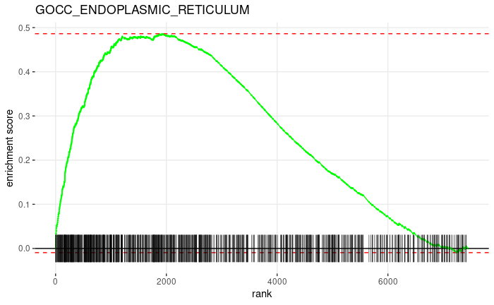

```r
plotEnrichment(c5_ontology[[fgseaSp5_ont[order(pval), ]$pathway[1]]],
               Sp5) + labs(title=fgseaSp5_ont[order(pval), ]$pathway[1])
```

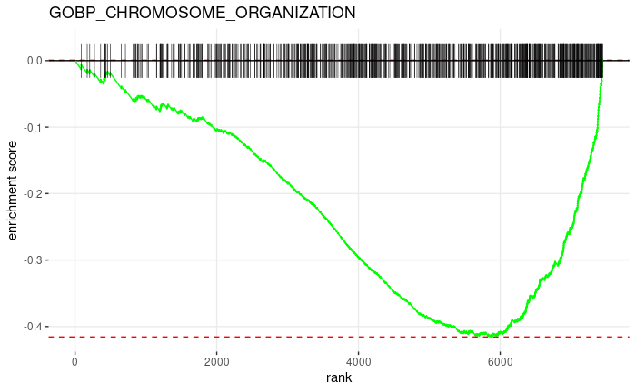

```r
plotEnrichment(c5_ontology[[fgseaSp5_ont[order(pval), ]$pathway[2]]],
               Sp5) + labs(title=fgseaSp5_ont[order(pval), ]$pathway[2])
```

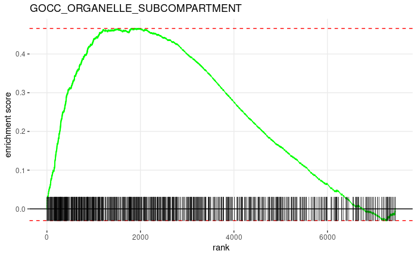

```r
plotEnrichment(c5_ontology[[fgseaSp5_ont[order(pval), ]$pathway[3]]],
               Sp5) + labs(title=fgseaSp5_ont[order(pval), ]$pathway[3])
```

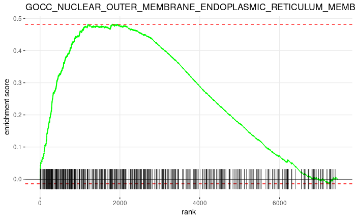

```r
plotEnrichment(c5_ontology[[fgseaSp5_ont[order(pval), ]$pathway[4]]],
               Sp5) + labs(title=fgseaSp5_ont[order(pval), ]$pathway[4])
```

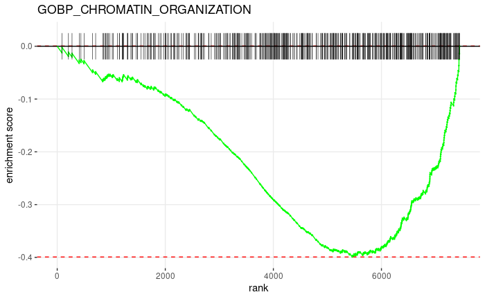

```r
plotEnrichment(c5_ontology[[fgseaSp5_ont[order(pval), ]$pathway[5]]],
               Sp5) + labs(title=fgseaSp5_ont[order(pval), ]$pathway[5])
```

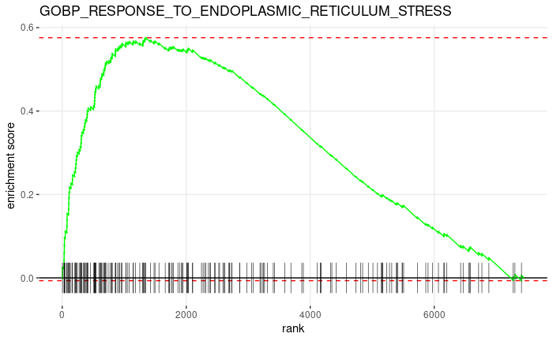

```r
plotEnrichment(c5_ontology[[fgseaSp5_ont[order(pval), ]$pathway[6]]],
               Sp5) + labs(title=fgseaSp5_ont[order(pval), ]$pathway[6])
```

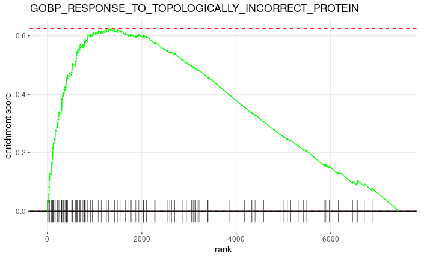

```r
plotEnrichment(c5_ontology[[fgseaSp5_ont[order(pval), ]$pathway[8]]],
               Sp5) + labs(title=fgseaSp5_ont[order(pval), ]$pathway[8])
```

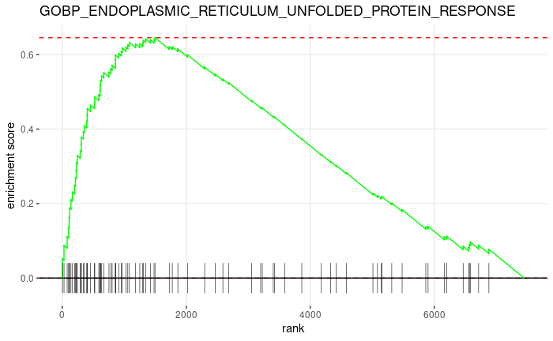

```r
plotEnrichment(c5_ontology[[fgseaSp5_ont[order(pval), ]$pathway[20]]],
               Sp5) + labs(title=fgseaSp5_ont[order(pval), ]$pathway[20])
```

##### leading edge analysis

```r
one <- fgseaSp5_ont %>% filter(pathway=="GOCC_ENDOPLASMIC_RETICULUM") %>% pull(leadingEdge) %>% unlist()
two <- fgseaSp5_ont %>% filter(pathway=="GOBP_RESPONSE_TO_ENDOPLASMIC_RETICULUM_STRESS") %>% pull(leadingEdge) %>% unlist()
three <- fgseaSp5_ont %>% filter(pathway=="GOBP_RESPONSE_TO_TOPOLOGICALLY_INCORRECT_PROTEIN") %>% pull(leadingEdge) %>% unlist()
four <- fgseaSp5_ont %>% filter(pathway=="GOBP_ENDOPLASMIC_RETICULUM_UNFOLDED_PROTEIN_RESPONSE") %>% pull(leadingEdge) %>% unlist()
```

```r
intersect(intersect(intersect(one, two), three), four)
```

```
 [1] "DERL3"    "PDIA5"    "HERPUD1"  "FICD"     "HSP90B1"  "HSPA5"    "WFS1"     "FKBP14"   "EXTL2"
[10] "SRPRB"    "DNAJC3"   "PDIA6"    "SERP1"    "CREB3L2"  "CALR"     "TMED2"    "EDEM1"    "PPP1R15A"
[19] "HYOU1"    "MBTPS1"   "DERL1"    "PREB"     "ATF6"     "AMFR"     "VCP"      "DDRGK1"   "SEC31A"
[28] "UFL1"     "SSR1"     "RHBDD2"   "TBL2"     "YIF1A"
```

including UPR list from Hallmark:

```r
intersect(intersect(intersect(intersect(one, two), three), four), hupr)
```

```
 [1] "PDIA5"   "HERPUD1" "HSP90B1" "HSPA5"   "WFS1"    "FKBP14"  "SRPRB"   "DNAJC3"  "PDIA6"   "SERP1"
[11] "CALR"    "EDEM1"   "HYOU1"   "PREB"    "ATF6"    "SEC31A"  "SSR1"
```

knocks out `DERL3` and several others but not `ATF6`

#### notes Sp5

UPR/ER/Golgi/protein secretion on the positive end, Chromatin/DNA/cell cycle on the negative end

negative enrichment scores: `HALLMARK_E2F_TARGETS` and `HALLMARK_G2M_CHECKPOINT` (related to cell cycle)  
positive enrichment score: `HALLMARK_UNFOLDED_PROTEIN_RESPONSE` (cellular stress response related to the endoplasmic reticulum)

interesting article: https://link.springer.com/article/10.1007/s12185-016-2016-0  
Abstract: “Bortezomib (BTZ), a proteasome inhibitor, was initially reported as an inhibitor of the NF-κB pathway, which plays a critical role in the pathogenesis of multiple myeloma (MM). The NF-κB activity of MM cells is mediated via two distinct pathways, canonical and non-canonical, which show opposing activity after BTZ treatment in MM cells. Recent studies of proteasome inhibition in MM cells reveal that the accumulation of unfolded proteins in the endoplasmic reticulum (ER), referred to as ER stress, triggered the activity of several pro-apoptotic factors and sources of cell stress, such as the accumulation of reactive oxygen species (ROS), which is considered to be the main mechanism of action of BTZ-induced apoptosis. Several factors associated with ER stress and unfolded protein response (UPR) have been identified with the sensitivity of BTZ treatment. Low levels of XBP1, ATF3, and ATF4, which regulate UPR and ER stress-induced apoptosis, have been observed in poor responders to BTZ treatment, and three other genes, KLF9, Nampt, and CDK5, are associated with response to BTZ-containing therapy. These findings contribute to a better understanding of the mechanisms underlying BTZ-induced apoptosis in MM cells; however, further study is needed to develop potential predictive biomarkers of efficacy of BTZ-containing therapy.”

this study: https://www.nature.com/articles/s41408-018-0062-y  
implicates the `DERL3` gene in MM, `DERL3` is the top gene in the several sets relating to ER used for the leading edge analysis above.  
also interesting: https://journals.plos.org/plosgenetics/article?id=10.1371/journal.pgen.1003225

review article on UPR and MM: https://link.springer.com/article/10.1007%2Fs00018-021-03756-3

`ATF6` gene is also in the combined list and is important in UPR. Review above says “ATF6 has also been proposed as a predictor of bortezomib sensitivity in MM cells since drug resistance evolves to reduce cellular dependence on the UPR by downregulation of ATF6 and XBP1 expression” and referenes: https://www.nature.com/articles/bcj201640

quick look at CoMMpass data there many people treated with bortezomib, often in combination with others…